# Homework 3

Tony Daza

1. Load the `{tidyverse}`, `{ggridges}`, and `{ISLR}` packages in the “setup” chunk. (Install any if needed.)
2. Run the following lines of code to read about and view the data we’ll use for this lab.
- Comment out line 26 after you run it, but putting a `#` at the start of the line.

```r
str(gss_cat)
View(gss_cat)
#gss_cat
```

3. Use `{ggplot2}` to create a histogram of `tvhours`. The plot should:
- Include a small amount of transparency so grid lines are visible under the histogram.
- Be a different color than the default
- Include meaningful axis labels
- Have a title and a subtitle

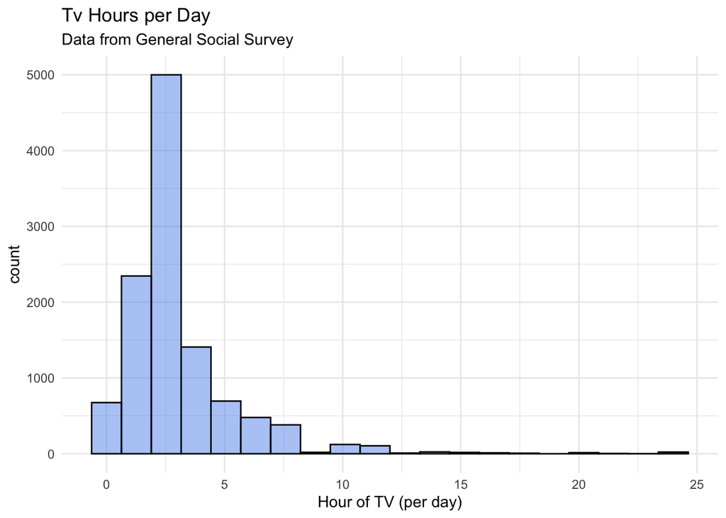

```r
#Histogram of Tv hours per day
gss_cat %>%
  ggplot(aes(x=tvhours))+
  geom_histogram(alpha=0.5, fill = 'cornflower blue', color = 'black',bins=20)+
  theme_minimal()+
  labs(title='Tv Hours per Day', subtitle = 'Data from General Social Survey', x='Hour of TV (per day)')
```

4. Create a ridgeline density plot of `age` by `partyid`. Do you notice any strong differences by party affiliation?

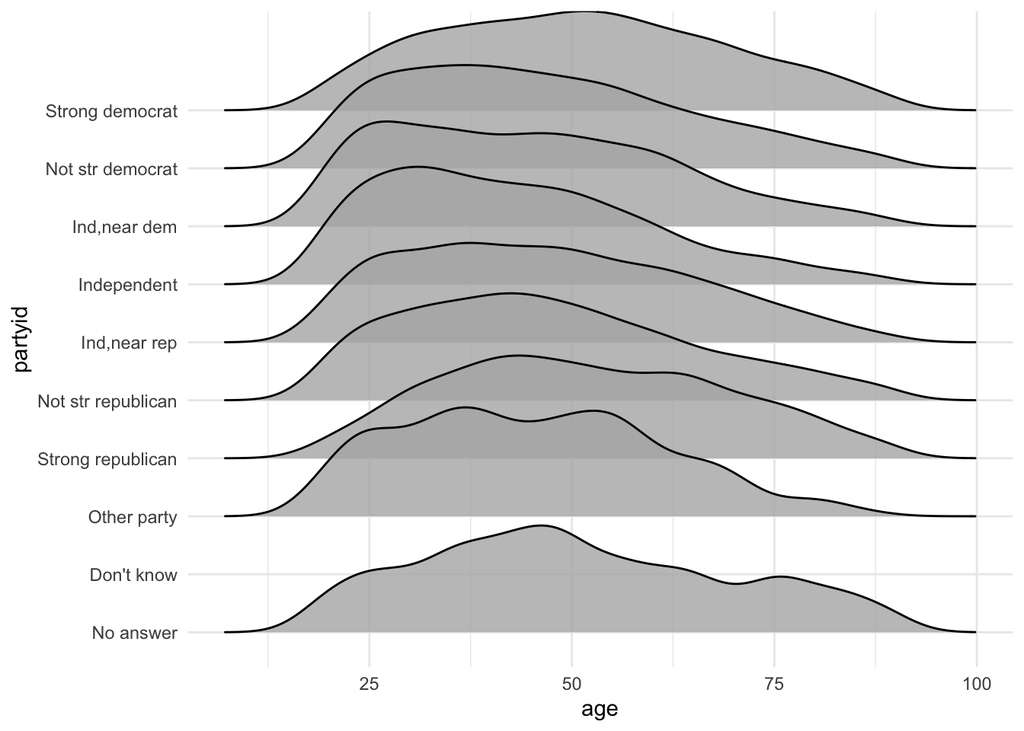

```r
#install.packages('ggridges')
library(ggridges)

ggplot(gss_cat, aes(x = age, y = partyid))+
  geom_density_ridges(alpha=0.8)+
  theme_minimal()
```

5. Modify the plot from Question 4 to produce separate ridgeline densities by `race` within one plot. Do you see any patterns?

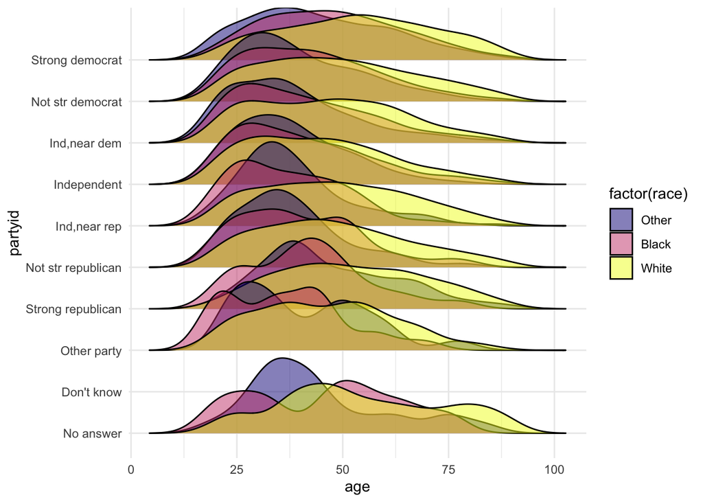

```r
ggplot(gss_cat, aes(x = age, y = partyid))+
  geom_density_ridges(aes(fill = factor(race)), alpha=0.5)+
  scale_fill_viridis_d(option = 'plasma')+
  theme_minimal()
```

There definitely seems to be a difference in party id by race. It seems like the peak for strong Republican is around 45ish and the peak for strong Democrat is a little after 50 across race. More black voters identified as ‘Other Party’ early on, around age 20, than other races and this trend persisted until about age 45 when more white voters identified as ‘Other party’.

6. Replicate the plots from Questions 4 and 5, but this time displaying the relations with boxplots (i.e., one boxplot from Question 4 and one boxplot for Question 5 in the chunk below). Try using `coord_flip`. Which do you think displays the relation more clearly? Why?

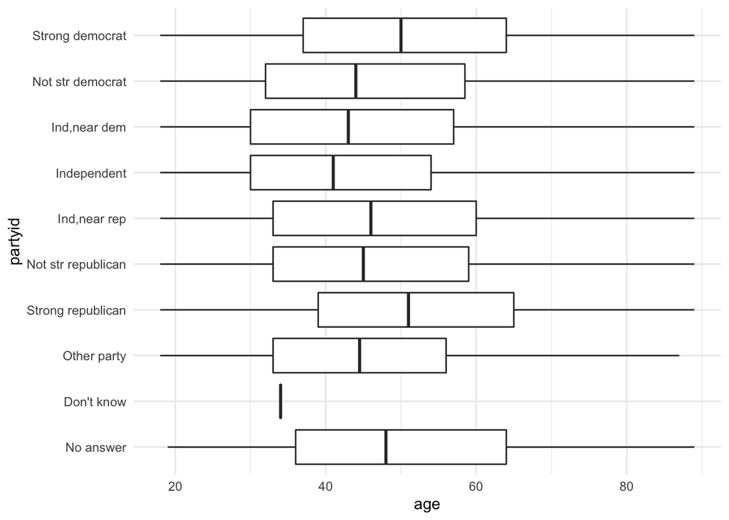

```r
ggplot(gss_cat, aes(x= age, y=partyid)) +
  geom_boxplot()+
  theme_minimal()
```

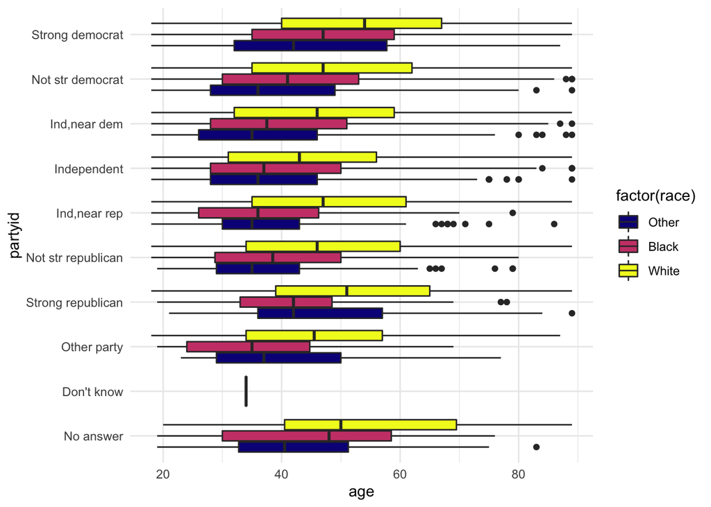

```r
ggplot(gss_cat, aes(x= partyid, y=age)) +
  geom_boxplot(aes(fill = factor(race)))+
  theme(axis.text.x = element_text(angle = 90, hjust = 1)) +
  coord_flip()+
  scale_fill_viridis_d(option = 'plasma')+
  theme_minimal()
```

Personally I find the density plot easier to read for the plot that is factored by race but for the simple graph of age and party id I find the boxplot easier to read. I do like a boxplot displays the outliers though. I am also more accustom to interpreting boxplots so that is a factor for me.

7. Run the following lines of code to get a correlation table as a data frame.

```r
cor_tbl <- Hitters %>%
  select_if(is.numeric) %>%
  cor(use = "pairwise.complete.obs") %>%
  as.data.frame() %>%
  mutate(row = row.names(.)) %>%
  gather(col, cor, -row) %>%
  tibble::as_tibble()
#I had to change the last line of code. From tbl_df to tibble::as_tibble()
```

Use the correlation table to create a heatmap using `geom_tile`. Change the colors to one of the four `viridis` palettes. What does the heatmap help you see?

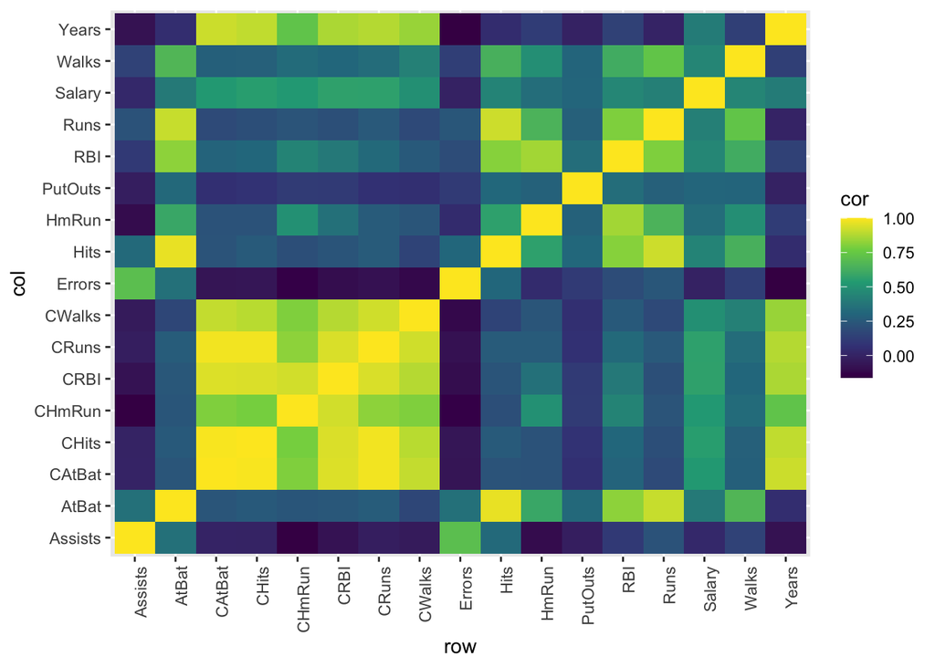

```r
ggplot(cor_tbl, aes(row,col,fill=cor))+
  geom_tile()+
  theme(axis.text.x = element_text(angle = 90, hjust = 1)) +
  scale_fill_viridis_c()
```

I don’t know much about these baseball terms but the heat map helps us see correlations between different variables. For example, there seems to be a strong correlation between ‘CAtBat’ and ‘CRuns’. The variable ‘Errors’ and ‘Assists’ also seems to have a strong correlation.

7. The code in the “barplot1” chunk below will produce a barplot.

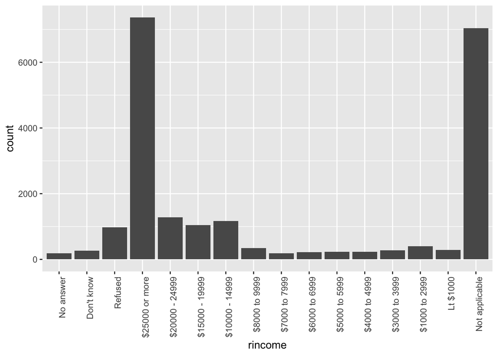

```r
ggplot(gss_cat, aes(rincome)) +
  geom_bar() +
  theme(axis.text.x = element_text(angle = 90, hjust = 1))
```

Use the code below to create a new data set - `gss_cat_new` - that redefines the `rincome` variable so that *Not applicable* is displayed first, followed by *No answer*, *Don’t know*, *Refused*, and then each income category from lowest to highest. Once you’ve redefined the factor variable, re-produce the plot above by running the `ggplot` code at the bottom of the chunk. The plot should have *Not applicable* closest to the *y*-axis, then *No answer*, *Don’t know*, etc.

```r
gss_cat_new <- gss_cat %>%
  mutate(rincome = factor(rincome, levels = c("Not applicable",
                                   "No answer",
                                   "Don't know",
                                   "Refused",
                                   "Lt $1000",
                                   "$1000 to 2999",
                                   "$3000 to 3999",
                                   "$4000 to 4999",
                                   "$5000 to 5999",
                                   "$6000 to 6999",
                                   "$7000 to 7999",
                                   "$8000 to 9999",
                                   "$10000 - 14999",
                                   "$15000 - 19999",
                                   "$20000 - 24999",
                                   "$25000 or more")))

ggplot(gss_cat_new, aes(rincome)) +
  geom_bar() +
  theme(axis.text.x = element_text(angle = 90, hjust = 1))+
  coord_flip()+
  theme_minimal()+
  labs(title = "Bar Graph of Reported Income", subtitle = "Data from General Social Survey", x="Reported Income")
```

[figure not shown]

The End